# Allele Specific Expression Analysis

Lachlan Baer

17 May, 2021

# Setup

```r
library(tidyverse)
library(magrittr)
library(parallel)
library(here)
library(AnnotationHub)
library(purrr)
library(scales)
library(kableExtra)
```

```r
if (interactive()) setwd(here::here())
theme_set(theme_bw())
cores <- detectCores() - 1
```

```r
source("~/bioinformatics/lbBioUtils/lbFuncs.R")
```

## EnsDb

```r
ah <- AnnotationHub() %>%
  subset(species == "Danio rerio") %>%
  subset(rdataclass == "EnsDb")
ensDb <- ah[["AH83189"]] ## Ens101
genes <- genes(ensDb)
mcols(genes) <- mcols(genes)[
  c("gene_id", "gene_name", "gene_biotype", "entrezid")
]
exons <- exonsBy(ensDb, by = "gene")
```

# Load data

## Metadata

```r
metadata <- read_csv(here("files/samples.csv")) %>%
  dplyr::select(-sample) %>%
  dplyr::rename(sample = basename, genotype = Genotype)
metadata %>%
  kable(
    align = "lllllll"
  ) %>%
  kable_styling(
    bootstrap_options = c("striped", "hover", "condensed", "responsive")
  )
```

| sample | fish_id | batch_killed | Sex | RINe | genotype | Genotype_2 |
| --- | --- | --- | --- | --- | --- | --- |
| 7_KB_B12 | 27 | 6 | F | 9.3 | EOfAD-like/+ | T428del/+ |
| 22_KB_C6 | 30 | 7 | F | 9.6 | EOfAD-like/+ | T428del/+ |
| 16_KB_C12 | 40 | 8 | F | 9.4 | EOfAD-like/+ | T428del/+ |
| 8_KB_B3 | 46 | 9 | F | 9.2 | EOfAD-like/+ | T428del/+ |
| 19_KB_C3 | 29 | 6 | M | 9.5 | EOfAD-like/+ | T428del/+ |
| 10_KB_B6 | 50 | 9 | M | 9.3 | EOfAD-like/+ | T428del/+ |
| 4_KB_A6 | 9 | 3 | M | 9.0 | EOfAD-like/+ | T428del/+ |
| 2_KB_A11 | 12 | 4 | F | 8.7 | fAI-like/+ | W233fs/+ |
| 12_KB_B8 | 22 | 5 | F | 9.3 | fAI-like/+ | W233fs/+ |
| 15_KB_C11 | 45 | 9 | F | 9.4 | fAI-like/+ | W233fs/+ |
| 18_KB_C2 | 47 | 9 | F | 9.2 | fAI-like/+ | W233fs/+ |
| 9_KB_B5 | 21 | 4 | M | 9.4 | fAI-like/+ | W233fs/+ |
| 6_KB_B11 | 26 | 6 | M | 9.4 | fAI-like/+ | W233fs/+ |
| 24_KB_C8 | 44 | 9 | M | 9.8 | fAI-like/+ | W233fs/+ |
| 21_KB_C5 | 49 | 9 | M | 9.5 | fAI-like/+ | W233fs/+ |
| 5_KB_A7 | 19 | 4 | F | 9.1 | WT | WT |
| 1_KB_A10 | 25 | 5 | F | 9.4 | WT | WT |
| 23_KB_C7 | 36 | 7 | F | 9.7 | WT | WT |
| 3_KB_A1 | 4 | 1 | F | 9.4 | WT | WT |
| 17_KB_C1 | 34 | 7 | M | 9.0 | WT | WT |
| 20_KB_C4 | 35 | 7 | M | 9.3 | WT | WT |
| 14_KB_C10 | 37 | 8 | M | 9.3 | WT | WT |
| 13_KB_B9 | 54 | 10 | M | 9.3 | WT | WT |
| 11_KB_B7 | 55 | 10 | M | 9.1 | WT | WT |

## Counts

Heterozygous SNPs detected by `ASEReadCounter` were recorded in a seperate `tsv` file for each sample. These were loaded into R as a list of tibbles containing the unprocessed raw data for ASE analysis.

```r
files <- list.files(
  "/hpcfs/users/a1647910/210408_psen1_fADfAI_snv/15_aseReadCounts",
  full.names = TRUE
)
samples <- basename(files) %>%
  str_remove(".tsv")
drChrs <- seq(1:25)
```

```r
aseCounts <- lapply(files, function(file){
  sample <- basename(file) %>%
    str_remove(".tsv")
  read_tsv(
    file,
    col_types = "cdcccdddddddd"
  ) %>%
    dplyr::filter(contig %in% as.character(drChrs)) %>%
    mutate(
      sample = sample,
      allele = paste0(refAllele, ",", altAllele)
    ) %>%
    left_join(metadata[,c("sample", "genotype")]) %>%
    dplyr::select(
      chromosome = contig, position, allele, refCount, altCount, totalCount,
      sample, genotype, lowMAPQDepth, lowBaseQDepth, rawDepth, otherBases,
      improperPairs
    )
}) %>%
  set_names(samples)
```

The number of genome-wide het-SNP positions as reported by `ASEReadCounter` ranged from 403,138 to 569,044 across all samples.

# Quality control

## ASEReadCounter

GATK tool `ASEReadCounter` calculates allele counts at a set of positions after applying filters specifically tuned for AE analysis of RNA-seq data. The filters operate on mapping quality, base quality, depth of coverage and overlapping paired reads. Each of these filters can be controlled by command-line arguments. The data in this analysis was generated with the following options:

- `--min-mapping-quality 10`
- `--min-base-quality 20`
- `--count-overlap-reads-handling COUNT_FRAGMENTS_REQUIRE_SAME_BASE`
- Ths option counts all fragments where the base is consistent when mate pairs overlap.
- `--min-depth-of-non-filtered-base -1`
- This argument is disabled, because depth filtering will be performed manually (see next section).

```r
filtProps <- aseCounts %>%
  purrr::reduce(rbind) %>%
  group_by(sample) %>%
  summarise(
    mapQ = sum(lowMAPQDepth) / sum(rawDepth),
    baseQ = sum(lowBaseQDepth) / sum(rawDepth),
    otherBases = sum(otherBases) / sum(rawDepth)
  )
```

With the above settings across all samples, reads filtered due to insufficient mapping quality ranged between 1.72% and 2.27%, reads filtered due to base quality ranged between 1.98% and 2.46%, and reads filtered due to overlapping mate pairs with inconsistent bases ranged between 0.12% and 0.15%.

More information about recommended quality control measures can be found in [Castel et al. Tools and Best Practices for allelic expression analysis.](https://www.biorxiv.org/content/biorxiv/early/2015/03/05/016097.full.pdf)

## Filtering

### Exonic variants

Since the variants originate from RNA-seq data, they were filtered based on genomic position for those that lie in only exonic regions (Ensembl version 101). Gene identifiers were also annotated for each position to enable downstream analysis of ASE across genes.

```r
exonOverlaps <- lapply(aseCounts, function(x){
  indices <- x %>%
    dplyr::select(seqnames = chromosome, start = position) %>%
    mutate(end = start) %>%
    makeGRangesFromDataFrame() %>%
    findOverlaps(exons)
  tibble(
    snpInd = as.data.frame(indices)$queryHits,
    geneInd = as.data.frame(indices)$subjectHits
  )
})
```

```r
counts <- lapply(seq_along(aseCounts), function(x){
  aseCounts[[x]][exonOverlaps[[x]]$snpInd,] %>%
    cbind(gene = names(exons[exonOverlaps[[x]]$geneInd])) %>%
    as_tibble() %>%
    rownames_to_column("snpID")
}) %>%
  set_names(samples)
```

After filtering for SNPs in exonic regions, the remaining number of het-SNPs ranged from 158,819 to 194,093 across all samples.

### Coverage

Another important QC step before ASE anyalysis involves filtering Het-SNP sites based on coverage, as sites with low total counts are uninformative.

Firstly, a quick inspection of coverage distribution was performed:

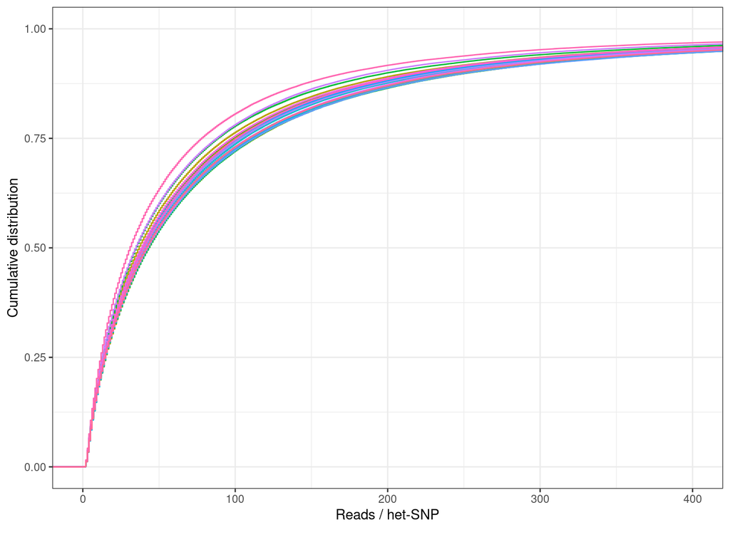

*Cumulative distribution of RNA-seq read coverage per het-SNP. Each line represents a separate sample.*

```r
counts %>%
  purrr::reduce(rbind) %>%
  ggplot(aes(totalCount, colour = sample)) +
  stat_ecdf(geom = "step") +
  coord_cartesian(xlim = c(0, 400)) +
  labs(
    x = "Reads / het-SNP",
    y = "Cumulative distribution",
    caption = ""
  ) +
  theme(legend.position = "none")
```

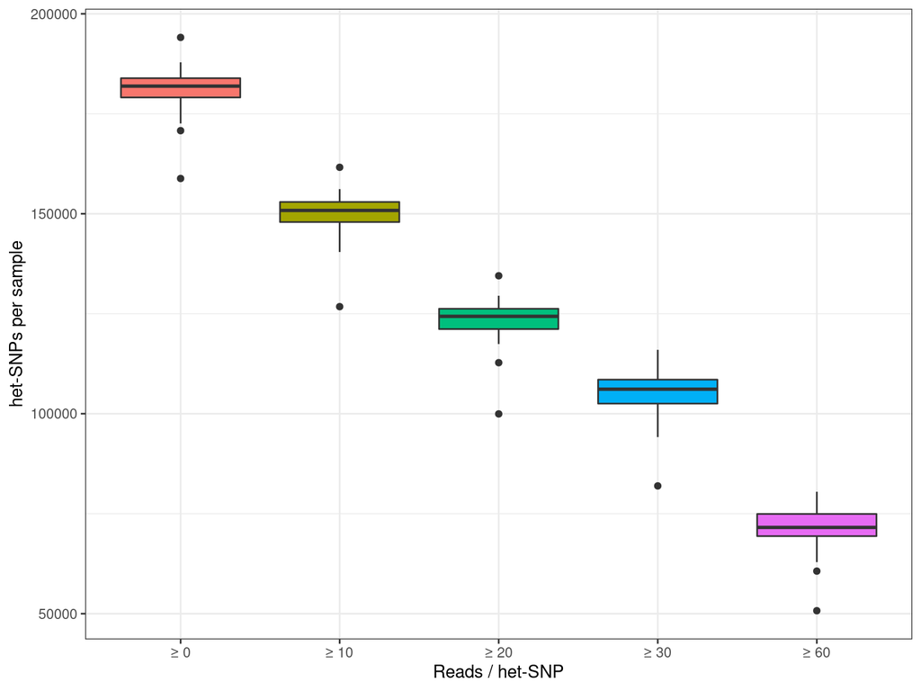

*The number of het-SNPs per sample that satisfy read coverage cut-offs*

```r
lapply(counts, function(x){
  n0 <- x %>%
    dplyr::filter(totalCount >= 0) %>%
    nrow()
  n10 <- x %>%
    dplyr::filter(totalCount >= 10) %>%
    nrow()
  n20 <- x %>%
    dplyr::filter(totalCount >= 20) %>%
    nrow()
  n30 <- x %>%
    dplyr::filter(totalCount >= 30) %>%
    nrow()
  n60 <- x %>%
    dplyr::filter(totalCount >= 60) %>%
    nrow()
  sample <- unique(x$sample)
  tibble(
    bin = c("\u2265 0", "\u2265 10", "\u2265 20", "\u2265 30", "\u2265 60"),
    n = c(n0, n10, n20, n30, n60),
    sample = sample
  )
}) %>%
  purrr::reduce(rbind) %>%
  ggplot(aes(bin, n, fill = bin)) +
  geom_boxplot() +
  labs(x = "Reads / het-SNP", y = "het-SNPs per sample") +
  theme(legend.position = "none")
```

```r
counts <- lapply(counts, function(x){
  dplyr::filter(x, totalCount >= 10)
})
```

A cut-off of at least 10 counts per het-SNP position was applied, leaving 126,774 to 161,614 het-SNPs across all samples.

### Mono-allelic expression

```r
counts <- lapply(counts, function(x){
  dplyr::filter(
    x,
    refCount >= 3,
    altCount >= 3,
    refCount / totalCount > 0.01,
    altCount / totalCount > 0.01
  )
})
```

After filtering for mono-allelic expression, 123,064 to 157,698 het-SNPs remained across all samples.

### Summary

```r
genesWithSnps <- lapply(counts, function(x){
  sample <- unique(x$sample)
  atLeast1 <- length(unique(x$gene))
  atLeast2 <- x %>%
    group_by(gene) %>%
    summarise(n = n()) %>%
    dplyr::filter(n >= 2) %>%
    nrow()
  snps <- nrow(x)
  tibble(sample = sample, atLeast1 = atLeast1, atLeast2 = atLeast2, snps = snps)
}) %>%
  purrr::reduce(rbind) %>%
  left_join(metadata[,c("sample", "genotype")]) %>%
  dplyr::arrange(genotype, sample)
```

The total number of genes and het-SNPs remaining after QC measures is summarised below:

```r
genesWithSnps %>%
  dplyr::select(
    Sample = sample, Genotype = genotype, Genes = atLeast1, SNPs = snps
  ) %>%
  kable(
    align = "lll",
    caption = paste(
      "Overall numbers of genes and SNPs detected in each sample after filtering."
    )
  ) %>%
  kable_styling(
    bootstrap_options = c("striped", "hover", "condensed", "responsive")
  )
```

Overall numbers of genes and SNPs detected in each sample after filtering.

| Sample | Genotype | Genes | SNPs |
| --- | --- | --- | --- |
| 10_KB_B6 | EOfAD-like/+ | 11654 | 150683 |
| 16_KB_C12 | EOfAD-like/+ | 11281 | 147128 |
| 19_KB_C3 | EOfAD-like/+ | 11301 | 146334 |
| 22_KB_C6 | EOfAD-like/+ | 11468 | 149621 |
| 4_KB_A6 | EOfAD-like/+ | 10891 | 136685 |
| 7_KB_B12 | EOfAD-like/+ | 11538 | 148246 |
| 8_KB_B3 | EOfAD-like/+ | 10187 | 123064 |
| 12_KB_B8 | fAI-like/+ | 11186 | 147300 |
| 15_KB_C11 | fAI-like/+ | 12046 | 157698 |
| 18_KB_C2 | fAI-like/+ | 11436 | 148906 |
| 2_KB_A11 | fAI-like/+ | 11424 | 147217 |
| 21_KB_C5 | fAI-like/+ | 11104 | 144807 |
| 24_KB_C8 | fAI-like/+ | 11304 | 148012 |
| 6_KB_B11 | fAI-like/+ | 11625 | 148907 |
| 9_KB_B5 | fAI-like/+ | 11769 | 152286 |
| 1_KB_A10 | WT | 10919 | 140527 |
| 11_KB_B7 | WT | 11632 | 151534 |
| 13_KB_B9 | WT | 11593 | 146246 |
| 14_KB_C10 | WT | 11205 | 147761 |
| 17_KB_C1 | WT | 11163 | 142274 |
| 20_KB_C4 | WT | 11322 | 145133 |
| 23_KB_C7 | WT | 10975 | 140470 |
| 3_KB_A1 | WT | 11415 | 145057 |
| 5_KB_A7 | WT | 10780 | 138454 |

## Reference mapping bias

An important aspect to consider in AE analysis is the potential for mapping bias. For RNA-seq data mapped to a reference genome, reads that carry an alternate allele at positions of variation have at least one mismatch, and therefore a lower probability of aligning correctly than reads containing the reference allele. To estimate this effect we can calculate the genome-wide reference ratio, which will indicate a reference mapping bias if above 0.5. This calculated ratio may be more suitable as the null in downstream statistical testing.

```r
ratios <- lapply(counts, function(x){
  x %>%
    dplyr::filter(totalCount != 0) %>%
    mutate(
      refRatio = refCount / totalCount,
      altRatio = altCount / totalCount
    ) %>%
    dplyr::select(
      chromosome, position, allele, refRatio, altRatio, totalCount,
      sample, genotype, gene
    )
})
```

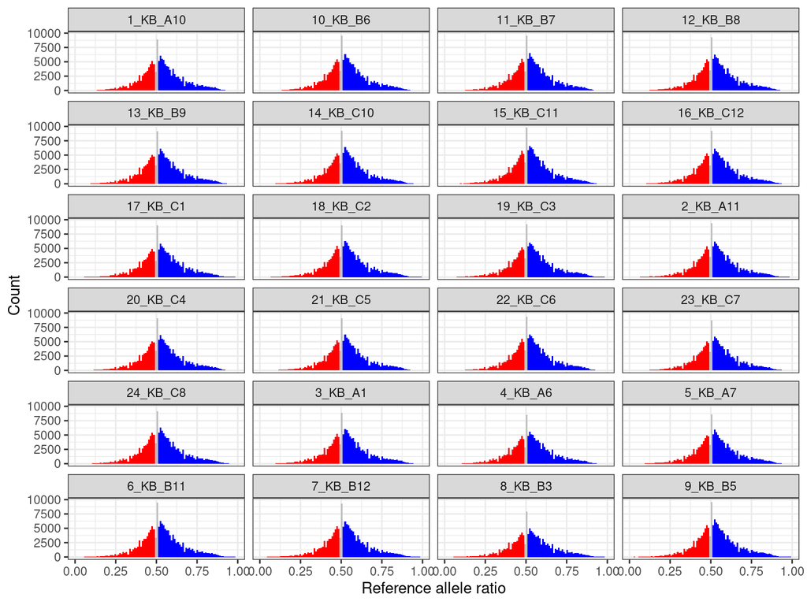

*Histogram of global reference allele ratios at each het-SNP faceted by sample. The distributions show a similar profile of reference mapping bias indicated by an inflation of reference allele ratios > 0.5. Allelic ratios above 0.51 are shown in blue and below 0.49 in red, while balanced expression (0.49-0.51) is coloured grey.*

```r
ratioDists <- purrr::reduce(ratios, rbind) %>%
  mutate(
    fill = ifelse(refRatio < 0.49, "less", NA),
    fill = ifelse(between(refRatio, 0.49, 0.51), "even", fill),
    fill = ifelse(refRatio > 0.51, "more", fill),
  )
ggplot(ratioDists, aes(refRatio)) +
  geom_histogram(
    data = subset(ratioDists, fill == "less"),
    bins = 100, fill = "red"
  ) +
  geom_histogram(
    data = subset(ratioDists, fill == "even"),
    bins = 100, fill = "grey"
  ) +
  geom_histogram(
    data = subset(ratioDists, fill == "more"),
    bins = 100, fill = "blue"
  ) +
  labs(x = "Reference allele ratio", y = "Count") +
  facet_wrap(~ sample, ncol = 4)
```

The mean reference mapping ratios were calculated for each sample. This value will be used as the null statistic for detecting ASE.

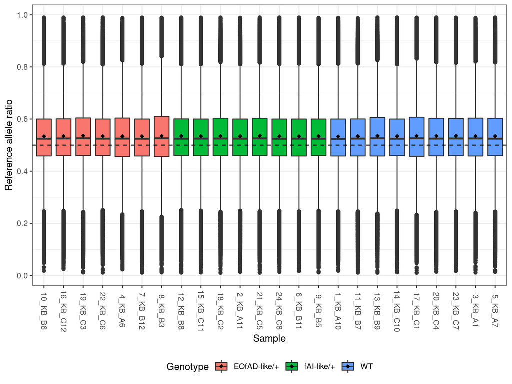

*Boxplots showing mapping bias for each sample. The mean reference ratio is indicated with a black diamond.*

```r
ratios %>%
  purrr::reduce(rbind) %>%
  left_join(metadata[,c("sample", "genotype")]) %>%
  dplyr::arrange(genotype, sample) %>%
  mutate(sample = factor(sample, levels = unique(sample))) %>%
  ggplot(aes(sample, refRatio, fill = genotype)) +
  geom_boxplot() +
  stat_summary(fun = mean, geom = "point", shape = 18, size = 2) +
  geom_hline(yintercept = 0.5, linetype = "dashed", colour = "black") +
  labs(x = "Sample", y = "Reference allele ratio") +
  scale_fill_discrete(name = "Genotype") +
  scale_y_continuous(breaks = seq(0, 1, 0.2)) +
  theme(
    axis.text.x = element_text(angle = -90, vjust = 0.5),
    legend.position = "bottom"
  )
```

```r
refBias <- ratios %>%
  purrr::reduce(rbind) %>%
  group_by(sample) %>%
  summarise(mean = mean(refRatio), median = median(refRatio))
altBias <- ratios %>%
  purrr::reduce(rbind) %>%
  group_by(sample) %>%
  summarise(mean = mean(altRatio), median = median(altRatio))
```

A reference mapping bias is evident across all samples. Mean reference ratios ranged between 0.533 and 0.536. Median reference ratios ranged between 0.524 and 0.526.

# Static ASE

## GeneiASE export

```r
staticCounts <- lapply(counts, function(x){
  x %>%
    left_join(altBias[,c("sample", "mean")]) %>%
    dplyr::select(
      gene, snpID, altCount, refCount, betabinom.p = mean
    )
})
lapply(seq_along(staticCounts), function(x){
  path <- paste0(
    "/hpcfs/users/a1647910/210408_psen1_fADfAI_snv/16_geneiASE/input/",
    names(staticCounts[x]),
    ".static.tsv"
  )
  if (!file.exists(path)) {
    if (!dir.exists(dirname(path))) {
      dir.create(dirname(path), recursive = TRUE)
    }
    write_tsv(staticCounts[[x]], path)
  }
})
```

## Results

```r
files <- list.files(
  "/hpcfs/users/a1647910/210408_psen1_fADfAI_snv/16_geneiASE/output",
  full.names = TRUE
)
```

```r
staticRes <- lapply(files, function(x){
  sample <- basename(x) %>%
    str_remove(".static.pval.tsv")
  read_tsv(x) %>%
    mutate(sample = sample) %>%
    dplyr::arrange(fdr)
}) %>%
  set_names(samples)
```